# Urban Insect Biodiversity: Effects of Drought-Tolerant Plants A Negative Binomial Approach

Using count data modeling to explore how plant choices shape urban insect communities in LA’s Mediterranean climate.

Quarto

MEDS

R

Statistical Modeling

Author

Affiliation

[Ixel M.](https://IIDonaji.github.io/)

Master of Environmental Data Science Program @ The Bren School (UCSB)

Published

December 12, 2025

# Background Information

Urban areas are expanding globally, yet we know little about how landscaping choices affect urban biodiversity. Cities are environmental gradients that consistently shape habitat quality and biodiversity [^1]. Los Angeles, a naturally arid Mediterranean climate, presents a unique opportunity to examine whether drought-tolerant landscaping supports insect diversity. Adams et al.(2020)[^2] sampled insects monthly at 30 sites across LA County in 2014, capturing variation in urbanization intensity and landscaping type, making it well-suited to test this question.

Find the full analysis code and data in my [GitHub repository here](https://github.com/IIDonaji/EDS-222-Final-Project)

## **Research Questions:**

Do drought-tolerant plants and temperature affect insect species richness in urban Los Angeles, after accounting for urbanization intensity?

# Directed Acyclic Graph (DAG)

A conceptual model representing the hypothesized causal relationships among variables:

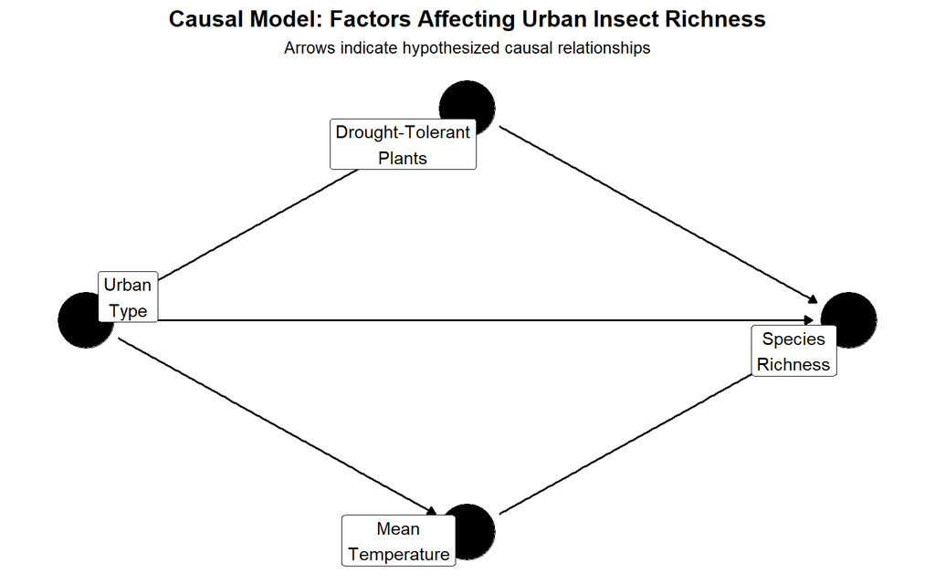

Figure 1: Causal diagram showing hypothesized relationships affecting species richness

## DAG explanation:

### **Direct effect on species richness:**

- **Drought-tolerant plants** (main predictor): Assume these plants provide better habitat for insects in LA’s arid climate.
- **Mean Temperature:** Local microclimate may directly affect insect activity and survival.
- **Urban Type:** Development intensity affects habitat quality and availability.

### **Confounding Relationships:**

Urbanization influences *both* plant choice (people in different urban contexts make different landscaping decisions) *and* local temperature (urban heat island effect), therefore we must control for urban type to isolate the effects of drought tolerant plants.

### **Importance:**

To estimate the *true effect* of drought-tolerant plants on species richness, we include both temperature and urbanization as covariates in the model. This accounts for the confounder and allows us to answer:

```
  "Do drought plants increase richness *independent* of urbanization and temperature?"
```

## **What the Arrows Mean:**

- Urbanization → Drought Plants: Urbanization affects which plants people choose.
- Urbanization → Temperature: Urban heat island (cities are hotter).
- Urbanization → Richness: Urbanization directly affects habitat quality.
- Drought Plants → Richness: Our main hypothesis (drought tolerant plants help insects).
- Temperature → Richness: Temperature affects insect survival.

The causal model shows that urbanization is a key confounder: it affects both plant choice and local temperature while also directly impacting species richness.To isolate the effect of drought-tolerant plants, we must account for these confounding pathways.

# Filter Data Before Analysis:

**Site-level aggregation:**

To avoid pseudoreplication from repeated monthly sampling, we averaged species richness and temperature across the year for each site, yielding 30 independent observations.

```r
# Aggregate to site level ( remove temporal pseudoreplication)
site_data <- insect_clean %>%
  group_by(Site, Drought, Urban_Category, Urban_Type) %>%
  summarise(
    mean_richness = mean(CorRich),
    mean_temp = mean(Temp_Mean),
    n_months = n(),
    .groups = "drop"
  )

# Quick check
glimpse(site_data)
```

```
Rows: 30
Columns: 7
$ Site           <fct> 1, 3, 4, 5, 6, 7, 8, 9, 10, 11, 12, 13, 14, 15, 16, 17,…
$ Drought        <fct> Yes, No, No, No, No, Yes, No, No, No, No, No, Yes, Yes,…
$ Urban_Category <fct> High, High, Less, Less, Less, Less, High, Moderate, Hig…
$ Urban_Type     <fct> 9, 9, 4, 3, 4, 3, 9, 5, 8, 8, 8, 1, 3, 9, 8, 6, 9, 9, 4…
$ mean_richness  <dbl> 3.0634921, 3.1666667, 2.2693122, 3.7380952, 4.6507937, …
$ mean_temp      <dbl> 19.32783, 19.49743, 18.62896, 19.57941, 19.47315, 19.76…
$ n_months       <int> 12, 12, 12, 12, 12, 12, 12, 12, 12, 12, 12, 12, 12, 12,…
```

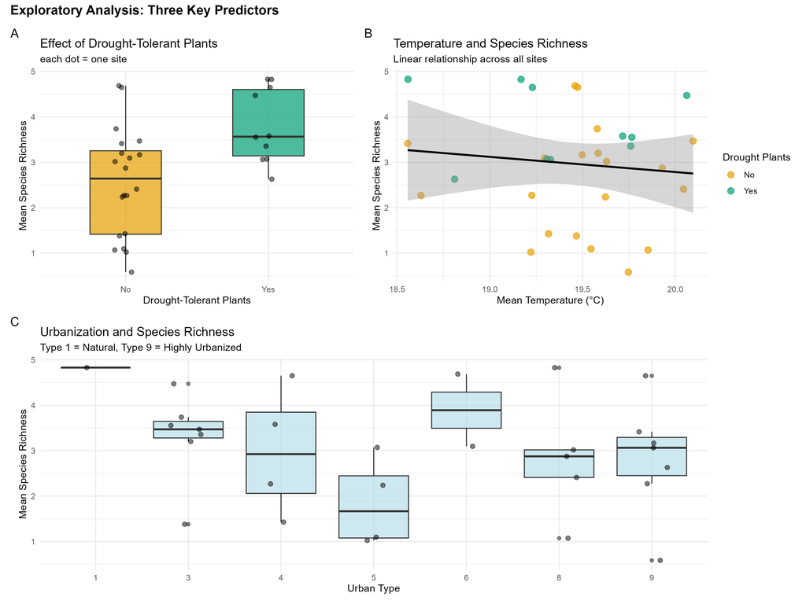

Figure 2: Exploratory analysis of mean insect species richness across 30 sites in Los Angeles County. (A) Sites with drought-tolerant plants show higher median richness than those without. (B) Weak negative relationship between mean temperature and species richness across all sites. (C) Species richness varies across urban types, with no clear monotonic trend from natural (Type 1) to highly urbanized (Type 9).

# Data Simulation According to Model Assumptions

**Using a Negative Binomial generalized linear model:**

$$\begin{align}
&\text{y} \sim \text{Negative Binomial}\,(\mu, \theta) \\
&log(\mu) = \beta_{0} + \beta_{1}\, \text{x}
\end{align}$$

**Why Negative Binomial?**

- Count data (species richness)
- More flexible than Poisson for ecological data
- Accounts for potential overdispersion

**Scientific Hypothesis 1:**

Sites with drought-tolerant plants have higher insect species richness than sites without drought-tolerant plants, after controlling for temperature and urbanization level.

**Statistical Hypotheses 1:**
$$\begin{align}
&H_0: \beta_1 = 0\ \text{Drought-tolerant plants have no effect} \\
&H_a: \beta_1 > 0\ \text{Drought-tolerant plants increase species richness} \\
\end{align}$$

**Interpretation 1:**

$\beta_1$ represents the effect of having drought-tolerant plants (Yes vs. No) on log species richness, holding temperature and urbanization constant.

**Scientific Hypothesis 2:** Local mean temperature is associated with insect species richness.

**Statistical Hypotheses 2:**
$$\begin{align}
&H_0: \beta_2 = 0 \quad \text{Temperature has no effect on species richness} \\
&H_a: \beta_2 \neq 0\quad \text{Temperature affect species richness}
\end{align}$$

**Interpretation:**

$\beta_2$ represents the effect of a 1°C increase in mean temperature on log species richness, holding drought plants and urbanization constant.

**Scientific Hypothesis 3:**

Urban Type affects insect species richness.

**Note:**

- $\beta_3$ = Moderate vs. Less Urbanized
- $\beta_4$ = High vs. Less Urbanized

# Model Validation: Parameter Recovery

To demonstrate the model is correctly specified, first simulated data with known parameter values, then fit the model to recover those parameters.

Below we will use the `glm.nb` function from the `MASS` package to estimate negative binomial regressions:

```r
set.seed(123) # For reproducibility

# set True Coefficients and parameters
beta_0 <- 1.0 # mean richness (baseline)
beta_1 <- 0.35 # Drought Tolerant plants presence
beta_2 <- 0.08 # mean temp
beta_3 <- 0.05 # Moderate vs low urban type
beta_4 <- -0.10 # High vs low urban type
theta <- 3 # Dispersion (NB size parameter)

# Sample size
n <- 100000

# Generate predictors
Drought <- factor(sample(c("No", "Yes"), n, replace = TRUE,
                    prob = c(0.67, 0.33)), # 33% yes, 67% no
                   levels = c("No", "Yes"))

mean_temp<- runif(n, min = 18.5, max = 20.1)

urban_Type <- factor(sample(c("Less", "Moderate", "High"), n, replace = TRUE),
  levels = c("Less", "Moderate", "High")
)

# Expected mean (inverse link of log)
mu <- exp(beta_0 + beta_1 * (Drought == "Yes") +
            beta_2 * mean_temp +
            beta_3 * (urban_Type == "Moderate") +
            beta_4 * (urban_Type == "High"))

# Generate random NB numbers
mean_richness <- rnbinom(n = n, size = theta, mu = mu)

#  Fit model to simulated data
simulation_model <- glm.nb(mean_richness ~ Drought + mean_temp + urban_Type)

# Print Coefficient
coef(simulation_model) %>%
  enframe(name = "Parameter", value = "Estimate") %>%
  kable(digits = 3, caption = "Simulated Model Coefficients")
```

Simulated Model Coefficients

| Parameter | Estimate |
| --- | --- |
| (Intercept) | 1.080 |
| DroughtYes | 0.357 |
| mean_temp | 0.076 |
| urban_TypeModerate | 0.056 |
| urban_TypeHigh | -0.098 |

# Compare estimated vs true parameters

```r
comparison <- tibble(
  Parameter = names(coef(simulation_model)),
  True_Value = c(beta_0, beta_1, beta_2, beta_3, beta_4), # type 2 through type 9 (type 1 is reference)
  Estimated = coef(simulation_model),
  Difference = abs(True_Value - Estimated),
  Recovered = abs(True_Value - Estimated) < 0.3  # Within 0.3 units?
)

kable(comparison, digits = 3,
      caption = "Parameter Recovery: True vs. Estimated Values")
```

Parameter Recovery: True vs. Estimated Values

| Parameter | True_Value | Estimated | Difference | Recovered |
| --- | --- | --- | --- | --- |
| (Intercept) | 1.00 | 1.080 | 0.080 | TRUE |
| DroughtYes | 0.35 | 0.357 | 0.007 | TRUE |
| mean_temp | 0.08 | 0.076 | 0.004 | TRUE |
| urban_TypeModerate | 0.05 | 0.056 | 0.006 | TRUE |
| urban_TypeHigh | -0.10 | -0.098 | 0.002 | TRUE |

**Results:**

- **Drought effect**: True $\beta_1$ = 0.35, Estimated $\beta_1$ = 0.35
- **Temperature effect**: True $\beta_2$ = 0.08, Estimated $\beta_2$ = 0.076

# Fit Negative Binomial model to Insect Data

```r
richness_model <- glm.nb(mean_richness ~ Drought + mean_temp + Urban_Type,
                          data = site_data)

summary(richness_model)$coefficients %>%
  kable(digits = 3, caption = "Model Summary")
```

Model Summary

|  | Estimate | Std. Error | z value | Pr(>\|z\|) |
| --- | --- | --- | --- | --- |
| (Intercept) | 2.933 | 6.833 | 0.429 | 0.668 |
| DroughtYes | 0.412 | 0.237 | 1.740 | 0.082 |
| mean_temp | -0.095 | 0.367 | -0.260 | 0.795 |
| Urban_Type3 | -0.047 | 0.677 | -0.070 | 0.944 |
| Urban_Type4 | -0.117 | 0.626 | -0.188 | 0.851 |
| Urban_Type5 | -0.583 | 0.679 | -0.858 | 0.391 |
| Urban_Type6 | 0.274 | 0.692 | 0.395 | 0.693 |
| Urban_Type8 | -0.110 | 0.683 | -0.162 | 0.872 |
| Urban_Type9 | -0.263 | 0.565 | -0.465 | 0.642 |

```r
confint(richness_model)%>%
  kable(digits = 3, caption = "95% Confidence Intervals")
```

95% Confidence Intervals

|  | 2.5 % | 97.5 % |
| --- | --- | --- |
| (Intercept) | -10.760 | 16.119 |
| DroughtYes | -0.058 | 0.873 |
| mean_temp | -0.804 | 0.639 |
| Urban_Type3 | -1.342 | 1.347 |
| Urban_Type4 | -1.310 | 1.185 |
| Urban_Type5 | -1.905 | 0.802 |
| Urban_Type6 | -1.067 | 1.685 |
| Urban_Type8 | -1.435 | 1.282 |
| Urban_Type9 | -1.317 | 0.944 |

# Test Hypothesis

```r
# Make predictions

# Predict richness across Drought levels
predict_rich_df <- expand_grid(
  Drought = levels(site_data$Drought), # "No", "Yes"
  mean_temp = seq(min(site_data$mean_temp),
                  max(site_data$mean_temp),
                  length.out = 200),
  Urban_Type = levels(site_data$Urban_Type) # "Less", "Moderate", "High"
)

# Generate predictions with standard errors
pred_out <- predict(object = richness_model,
                     newdata = predict_rich_df,
                     type = "response",  # Get predictions on count scale
                   se.fit = TRUE)

# Combine predictions with original grid
pred_df <- predict_rich_df %>%
  mutate(
    pred = pred_out$fit, # Predicted mean richness
    se = pred_out$se.fit, # Standard error
    lower = pred - 1.96 * se, # 95% CI lower bound
    upper = pred + 1.96 * se # 95% CI upper bound
  )

# Preview predictions
head(pred_df) %>% kable(digits = 3, caption = "Predicted Species Richness (first 6 rows)")
```

Predicted Species Richness (first 6 rows)

| Drought | mean_temp | Urban_Type | pred | se | lower | upper |
| --- | --- | --- | --- | --- | --- | --- |
| No | 18.557 | 1 | 3.201 | 1.642 | -0.017 | 6.418 |
| No | 18.557 | 3 | 3.052 | 1.557 | 0.001 | 6.104 |
| No | 18.557 | 4 | 2.846 | 1.168 | 0.558 | 5.134 |
| No | 18.557 | 5 | 1.787 | 0.875 | 0.072 | 3.502 |
| No | 18.557 | 6 | 4.208 | 1.969 | 0.349 | 8.067 |
| No | 18.557 | 8 | 2.866 | 1.406 | 0.110 | 5.622 |

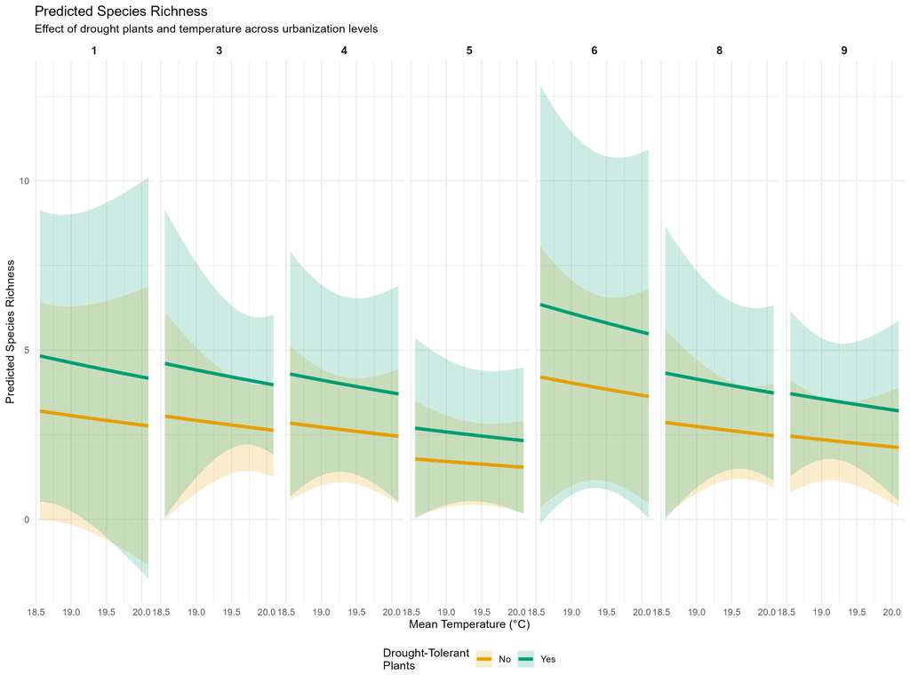

Figure 3 (facet by Urban Type): Predicted insect species richness as a function of mean temperature and drought-tolerant plant presence across urban type (1= natural, 9 = highly urbanized). Shaded bands represent 95% confidence intervals.

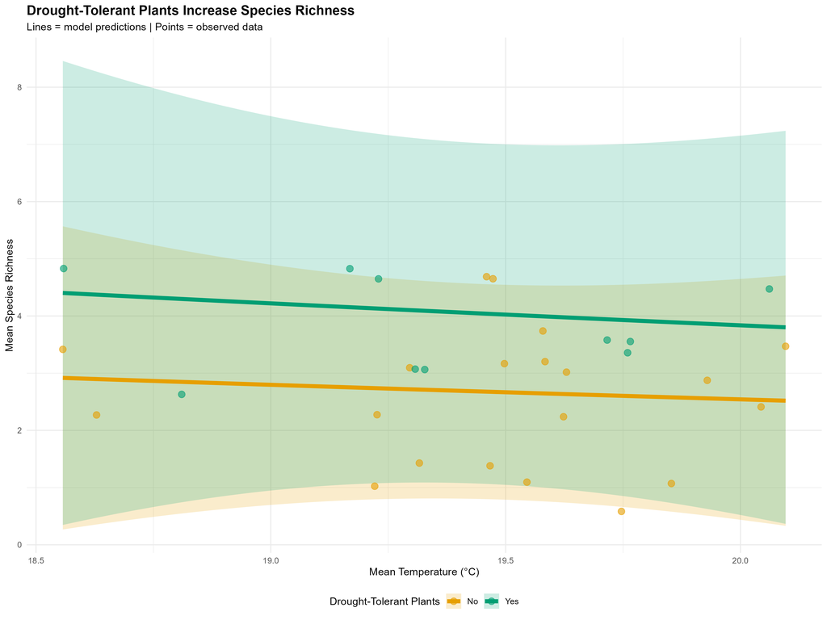

Figure 4 ( average across urban types): Predicted mean insect species richness across the observed temperature range for sites with (green) and without (orange) drought-tolerant plants. Lines show model predictions average across urban types; points are observed site-level data. Shaded bands represent 95% confidence intervals.

## Discussion

This results suggest a positive association between drought-tolerant landscaping and insect diversity, though the wide confidence intervals indicate uncertainty in the estimate.

1. **Climate-appropriate landscaping matters:**

2. **Practical application:**

Homeowners and urban planners can support biodiversity through plant selection

3. **Limitations:**
   - Observational data (can’t prove causation definitively)
   - Limited to Los Angeles (may not generalize)
   - Averaged across seasons (can’t examine temporal dynamics)
4. **Future directions:**
   - Experimental manipulation of plant types
   - Mechanism testing (why do drought plants help?)
   - Multi-city comparisons

## Conclusion

```r
results_table <- data.frame(
  Parameter = "Drought-Tolerant Plants",
  Coefficient = round(beta_drought, 3),
  Rate_Ratio = round(rate_ratio, 3),
  Percent_Increase = round(percent_increase, 1),
  CI_Lower = round(ci_rate_ratio[1], 3),
  CI_Upper = round(ci_rate_ratio[2], 3),
  P_Value = format.pval(p_value, digits = 3)
)

results_table %>%
  kable(digits = 3, caption = "Model Results: Effect of Drought-Tolerant Plants")
```

Model Results: Effect of Drought-Tolerant Plants

[output not shown]

#### Analysis conducted in R version [4.5.1] using:

- MASS (glm.nb)
- tidyverse (data manipulation)
- ggdag (causal diagrams)

## Footnotes

[^1]: Nancy B. Grimm et al.,(2008) Global Change and the Ecology of Cities.Science 319(5864),756-760.[DOI:10.1126/science.1150195](https://www.science.org/doi/10.1126/science.1150195)
[^2]: Adams, Benjamin et al.,(2020) Local and landscape scale variables shape insect diversity in an urban biodiversity hot spot 30(4).[DOI:e02089.10.1002/eap.2089](https://esajournals.onlinelibrary.wiley.com/doi/10.1002/eap.2089)